# **Wheelie Wonka Bikes**

Fidel González, Jesús Hernández, David Rojas y Mónica Contreras

mayo de 2021

# 1. Introducción

Wheelie Wonka Bike es una empresa de renta de bicicletas que opera actualmente en Boston con 142 estaciones. Se identificó que Una de las principales variables que toma el cliente para utilizar las bicicletas es la disponibilidad de estas en la estacion más cercana.

Para que el cliente tenga una mejor experiencia y aumentar el número de usuarios, se realizó un análisis que tiene por objetivo informar a los usuraios, en tiempo real, el número de bicicletas disponibles por cada estación.

# 2. Objetivo

El objetivo del análisis que se presenta a continuación es estimar el número bicicletas que llegan a cada estación cada 10 minutos, con ello poderles brindar un mejor servicio a nuestros clientes.

# 3. Estadística descriptiva

Para este análisis se cueenta con tres bases de datos, trips, stations y weathers. Los cuales se detallan a continuación:

*Trips*

Esta base contiene observaciones correspondientes a cada viaje y se incluye información de la estación de dónde partió a donde entro; incluye también el día y la hora en la cual se inicio y finaliza el viaje; características de las personas como género, zip code; fecha de nacimiento y si los usuarios estan registrados o no. El número total de viajes es 1,578,973 entre Julio 2011 y Noviembre 2013.

*Stations*

En esta base se incluye información geográfica de las estaciones. En total hay 142 estaciones activas en la base; adicionalmente en esta base encontramos infomración geografica de las estaciones como latitu y longitud. Esta base nos permitirá hacer un análisis sobre las ditancias de cada viaje.

*Weather*

Esta base contiene todas las horas en las que hubo lluvia y la intensidad de esta. Esto nos permitira saber en cuales viajes se presentó lluvia.

## Análisis descriptivo

*Distribución de la duración por viaje*

Nuestro análisis arrojó que la gran mayoría de los viajes son de una duración menor a 30 minutos.

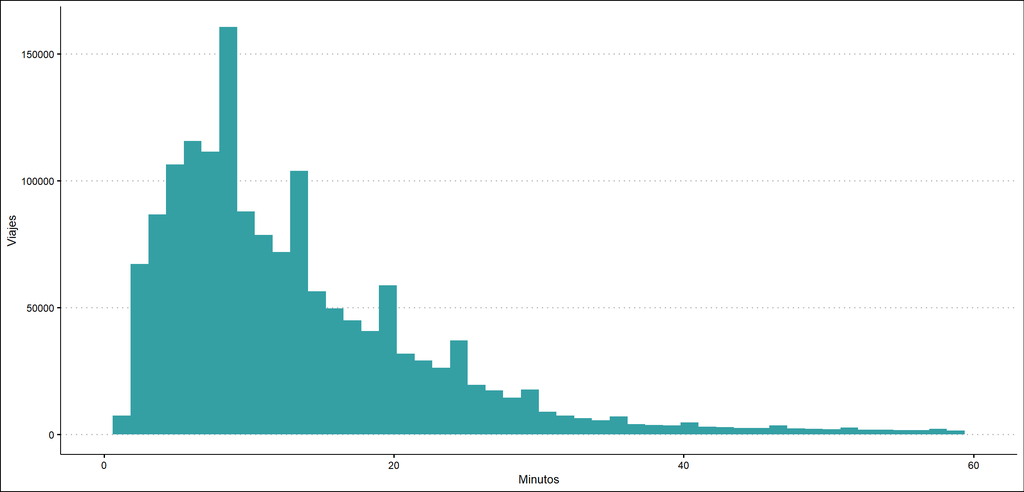

```r
#Histograma de duración
ggplot(data = trips, aes(x = duration / 60)) +
  geom_histogram(bins = 50, fill = "#34a0a4") +
  theme_clean() +
  xlim(0, 60) +
  xlab("Minutos") +
  ylab("Viajes")
```

Es importante mencionar que procedimos a eliminar outliers de la base. Decidimos eliminar todas aquellas observaciones muy por encima de lo observado, al ver el histograma, el punto de corte lo decidimos en 22000 (seis horas).

*Análisis de viajes por características del cliente*

Análizando por genero se observa que la mayoría de los usuarios son hombres, sin embargo, hay una propoción considerable de observaciones sin género asignado. El número de viajes casuales coincide con el número de viajes sin género asignado.

```r
kbl(prop.table(table(trips$gender)),col.names=c("Género","Porcentaje"),digits=2) %>%
  kable_styling()
```

| Género | Porcentaje |
| --- | --- |
| Female | 0.17 |
| Male | 0.53 |
| Other | 0.30 |

Por otro lado, analizando los viajes por tipo de suscripción, se observa que el 70% de los usuarios son registrados mientras que el 30% es casual.

```r
kbl(prop.table(table(trips$subsc_type)), col.names = c("Tipo de viaje", "Porcentaje"), digits = 2) %>%
  kable_styling()
```

| Tipo de viaje | Porcentaje |
| --- | --- |
| Casual | 0.3 |
| Registered | 0.7 |

Al observar los viajes por tipo de cliente se puede ver que ambas distribuciones son similares, destacando que en noviembre los usuarios casuales presentan una mayor disminución que los registrados.

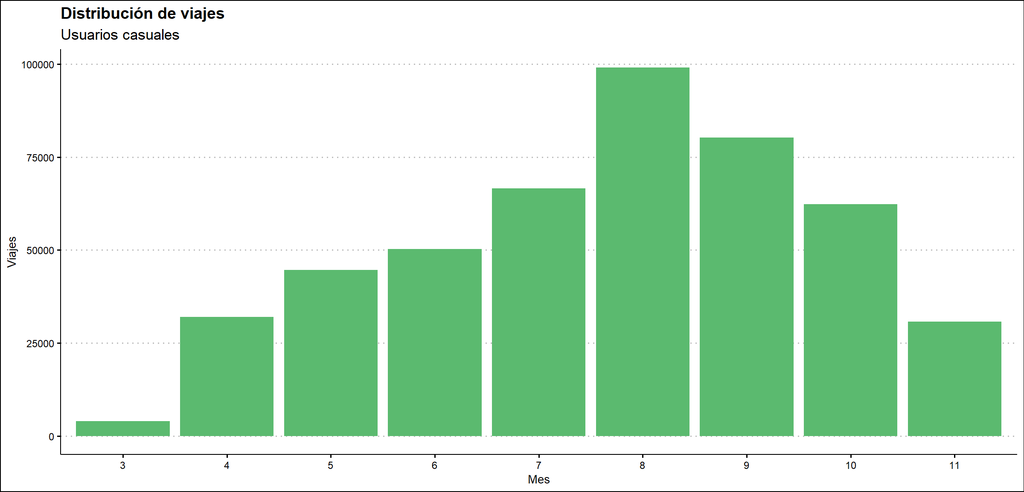

```r
trips %>%
  filter(subsc_type == "Casual") %>%
  ggplot(aes(x = month)) +
  geom_bar(bins = 12, fill = "#5bba6f") +
  labs(
    title = "Distribución de viajes",
    subtitle = "Usuarios casuales",
    x = "Mes",
    y = "Viajes"
  ) +
  theme_clean()
```

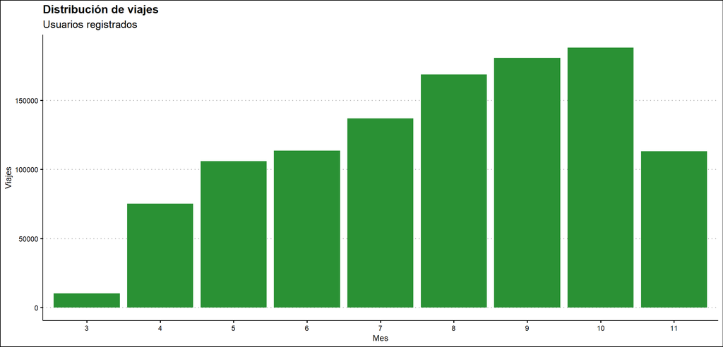

```r
trips %>%
  filter(subsc_type == "Registered") %>%
  ggplot(aes(x = month)) +
  geom_bar(bins = 12, fill = "#2a9134") +
  labs(
    title = "Distribución de viajes",
    subtitle = "Usuarios registrados",
    x = "Mes",
    y = "Viajes"
  ) +
  theme_clean()
```

*Análisis temporal*

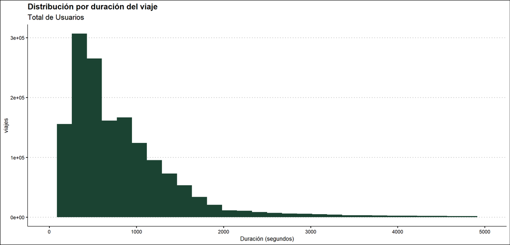

```r
trips %>%
  filter(90 < duration & duration < exp(10)) %>%
  ggplot(aes(x = duration)) +
  geom_histogram(fill = "#1b4332") +
  xlim(0, 5000) +
  labs(
    title = "Distribución por duración del viaje",
    x = "Duración (segundos)",
    subtitle = "Total de Usuarios",
    y = "viajes"
  ) +
  theme_clean()
```

```r
# mean(trips$duration)
```

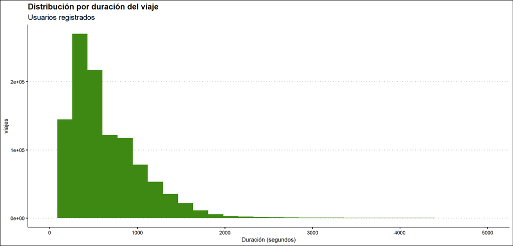

```r
trips %>%
  filter(90 < duration & duration < exp(10), subsc_type == "Registered") %>%
  ggplot(aes(x = duration)) +
  geom_histogram(fill = "#3e8914") +
  xlim(0, 5000) +
  labs(
    title = "Distribución por duración del viaje",
    subtitle = "Usuarios registrados",
    x = "Duración (segundos)",
    y = "viajes"
  ) +
  theme_clean()
```

```r
# mean(trips$duration)
```

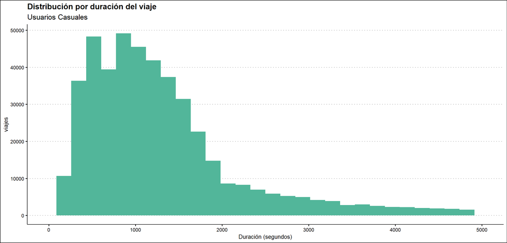

```r
trips %>%
  filter(90 < duration & duration < exp(10), subsc_type == "Casual") %>%
  ggplot(aes(x = duration)) +
  geom_histogram(fill = "#52b69a") +
  xlim(0, 5000) +
  labs(
    title = "Distribución por duración del viaje",
    subtitle = "Usuarios Casuales",
    x = "Duración (segundos)",
    y = "viajes"
  ) +
  theme_clean()
```

```r
# mean(trips$duration)
```

Respecto a la distribución de los viajes por día de la semana, observamos que ésta es relativamente constante, observando una ligera disminución en sábado y domingo y mayor uso los miércoles.

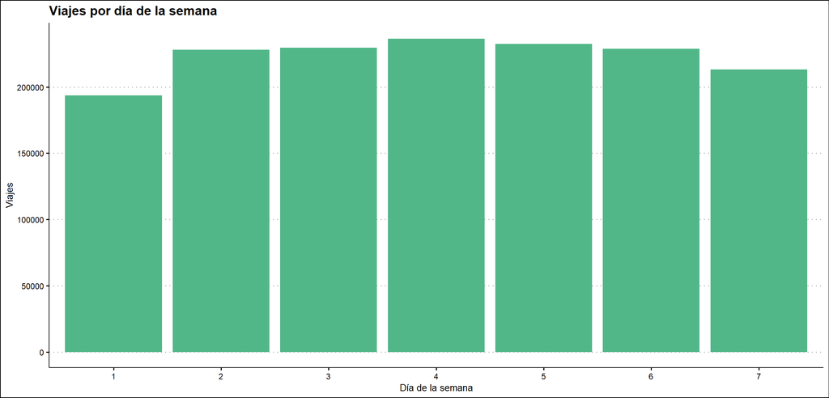

```r
trips %>%
  ggplot(aes(x = day_w)) +
  geom_bar(stat = "count", fill = "#52b788") +
  labs(
    title = "Viajes por día de la semana",
    x = "Día de la semana",
    y = "Viajes"
  ) +
  theme_clean()
```

Dado que los miércoles es el día más concurrido se procedio a hacer un análisis por horas, se observa que las horas mas concurridas son las 8:00 am y las 5:00 pm. Esto puede estar relacionado con las horas de entrada y salida de oficina.

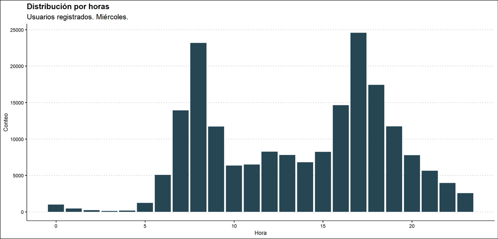

```r
trips %>%
  filter(
    subsc_type == "Registered",
    day_w == 4
  ) %>%
  ggplot(aes(x = hour)) +
  geom_bar(fill = "#264653") +
  labs(
    title = "Distribución por horas",
    subtitle = "Usuarios registrados. Miércoles.",
    x = "Hora",
    y = "Conteo"
  ) +
  theme_clean()
```

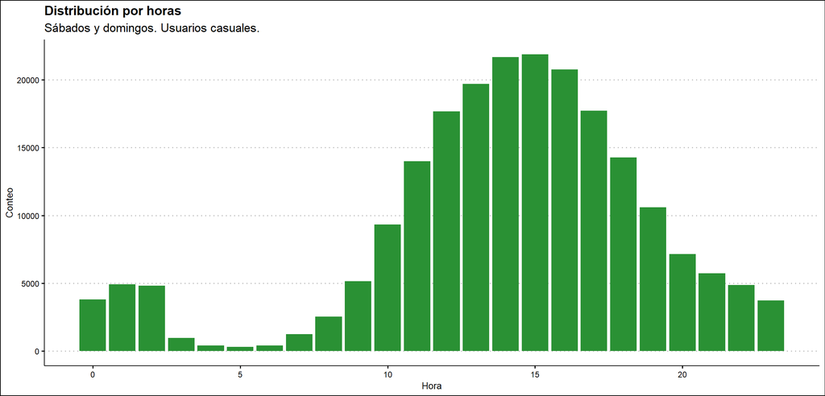

```r
trips %>%
  filter(
    subsc_type == "Casual",
    day_w %in% c(1, 7)
  ) %>%
  ggplot(aes(x = hour)) +
  geom_bar(fill = "#2a9134") +
  labs(
    title = "Distribución por horas",
    subtitle = "Sábados y domingos. Usuarios casuales.",
    x = "Hora",
    y = "Conteo"
  ) +
  theme_clean()
```

*Viajes por mes*

Realizando un análisis por meses observamos que el pico de uso es de agosto a octubre. De octubre a noviembre hay un descenso drástico y de diciembre a febrero no hay viajes, ello debido al invierno. En En marzo comienzan algunos y en abril cuando el clima mejora.

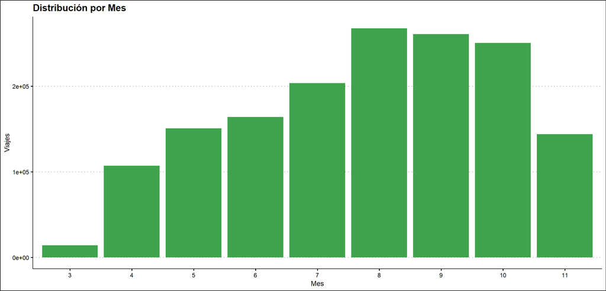

```r
trips %>%
  ggplot(aes(x = month)) +
  geom_bar(bins = 12, fill = "#3fa34d") +
  labs(
    title = "Distribución por Mes",
    x = "Mes",
    y = "Viajes"
  ) +
  theme_clean()
```

[figure not shown]

```r
trips %>%
  filter(
    subsc_type == "Registered",
    day_w %in% c(1, 7),
    month %in% c(6, 9)
  ) %>%
  ggplot(aes(x = hour, fill = month)) +
  geom_bar(alpha = 0.75, position = position_dodge()) +
  labs(
    title = "Distribución por horas",
    subtitle = "Domingos de junio y septiembre",
    x = "Hora",
    y = "Conteo"
  ) +
  theme_clean()
```

## Análisis geográfico

En el 96% de los viajes, los usuarios toman la bicicleta en una estación y la dejan en otra estación. Las rutas tomadas, considerando la estación de inicio y de fin, son otro pedazo de información que podemos generar con los datos disponibles. Hay 13706 rutas diferentes observadas a nivel estación en total.

Cuando hacemos el análisis de rutas a nivel municipio, podemos ver que casi el 70% de los viajes son dentro del municipio de Boston. El 14% de los viajes son entre Boston y Cambridge, mientras que el 10% son dentro de Cambridge . El restante 6% corresponde a la combinación de otros municipios.

```r
# Agrego columna indicadora si salió y llego al mismo lugar
trips <- trips %>% mutate(
  misma_estacion =
    case_when(
      strt_statn == end_statn ~ 1,
      TRUE ~ 0
    )
)

# trips %>% group_by(misma_estacion) %>% count() %>%
# mutate(proporcion=round(n/nrow(trips),2))
library(kableExtra)
kbl(trips %>% group_by(ruta_municipio) %>% count() %>% arrange(desc(n)) %>%
  mutate(proporcion = round(n / nrow(trips), 2)) %>%
  rename(Municipios = ruta_municipio, Viajes = n, Proporción = proporcion)) %>%
  kable_styling()
```

| Municipios | Viajes | Proporción |
| --- | --- | --- |
| Boston_Boston | 1076844 | 0.69 |
| Cambridge_Cambridge | 159949 | 0.10 |
| Boston_Cambridge | 111089 | 0.07 |
| Cambridge_Boston | 110185 | 0.07 |
| Cambridge_Somerville | 21016 | 0.01 |
| Somerville_Cambridge | 20779 | 0.01 |
| Boston_Brookline | 14859 | 0.01 |
| Brookline_Boston | 14584 | 0.01 |
| Somerville_Somerville | 12430 | 0.01 |
| Boston_Somerville | 6082 | 0.00 |
| Somerville_Boston | 5911 | 0.00 |
| Brookline_Brookline | 2971 | 0.00 |
| Brookline_Cambridge | 2740 | 0.00 |
| Cambridge_Brookline | 2576 | 0.00 |
| Somerville_Brookline | 144 | 0.00 |
| Brookline_Somerville | 107 | 0.00 |

Primero, con un par de mapas observamos donde terminan los viajes entre semana en comparación a los fines de semana. Es claro que entre semana los viajes se concentran en el centro de la ciudad, mientras que en el fin de semana hay una distribución un poco más uniforme.

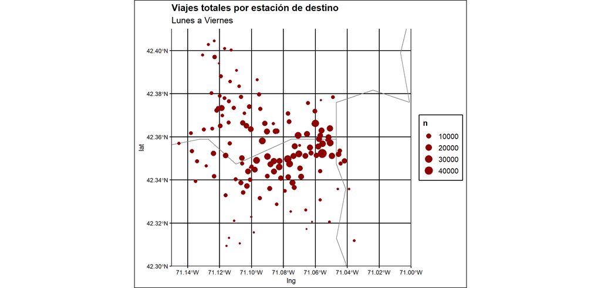

```r
world <- ne_countries(scale = "medium", returnclass = "sf")

counties <- st_as_sf(map("county", plot = FALSE, fill = TRUE))
counties <- subset(counties, grepl("massachusetts", counties$ID))
counties$area <- as.numeric(st_area(counties))

ggplot(data = world) +
  geom_sf(data = counties, fill = NA, color = gray(.5)) +
  geom_point(data = estaciones_semana_destino, aes(x = lng, y = lat, size = n), color = "darkred") +
  coord_sf(xlim = c(-71.15, -71.0), ylim = c(42.3, 42.41), expand = FALSE) +
  labs(
    title = "Viajes totales por estación de destino",
    subtitle = "Lunes a Viernes"
  ) +
  theme_clean()
```

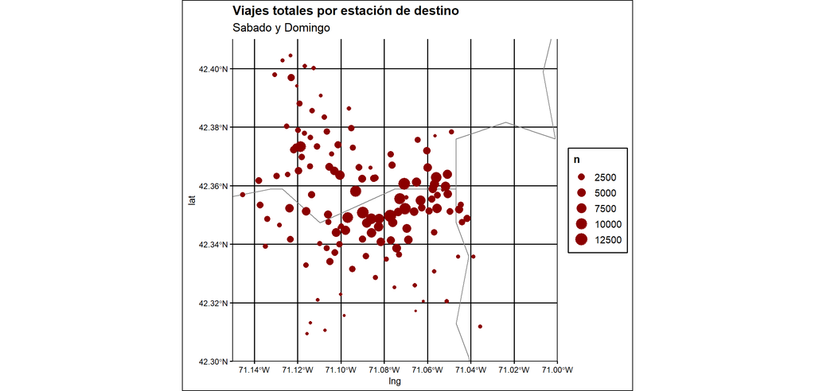

```r
ggplot(data = world) +
  geom_sf(data = counties, fill = NA, color = gray(.5)) +
  geom_point(data = estaciones_fin_destino, aes(x = lng, y = lat, size = n), color = "darkred") +
  coord_sf(xlim = c(-71.15, -71.0), ylim = c(42.3, 42.41), expand = FALSE) +
  labs(
    title = "Viajes totales por estación de destino",
    subtitle = "Sabado y Domingo"
  ) +
  theme_clean()
```

Ahora procedemos a analizar la base de datos con el objetivo de sacar persepectivas en cuanto a la distribución geográfica de las partidas y llegadas en horas pico. Este análisis lo mostramos en dos periodos del día, en la mañana (6:00 a 9:00) y en la tarde de (16:00 a 19:00) que como vimos son las horas pico. Estas gráficas corresponden a los viajes hechos entre semana.

La siguientes dos gráficas muestran el número de viajes por estación de partida y destino, respectivamente. En ellas se puede observará las estaciones más concurridas en los dos periodos.

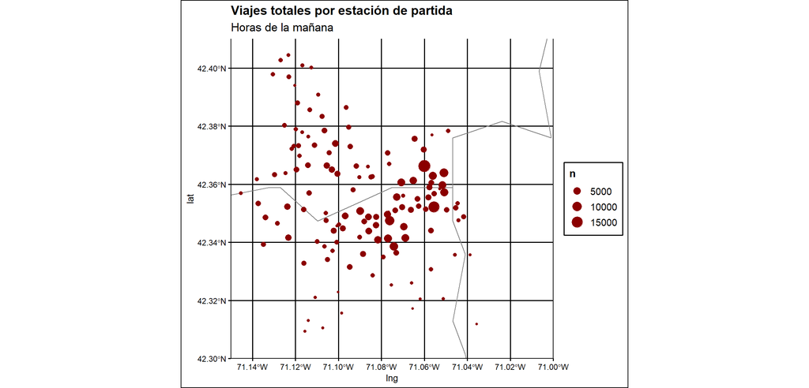

```r
#Para mapas
world <- ne_countries(scale = "medium", returnclass = "sf")
counties <- st_as_sf(map("county", plot = FALSE, fill = TRUE))
counties <- subset(counties, grepl("massachusetts", counties$ID))
counties$area <- as.numeric(st_area(counties))


ggplot(data = world) +
  geom_sf(data = counties, fill = NA, color = gray(.5)) +
  geom_point(
    data = estaciones_morn, aes(x = lng, y = lat, size = n),
    color = "darkred"
  ) +
  coord_sf(xlim = c(-71.15, -71.0), ylim = c(42.3, 42.41), expand = FALSE) +
  labs(
    title = "Viajes totales por estación de partida",
    subtitle = "Horas de la mañana"
  ) +
  theme_clean()
```

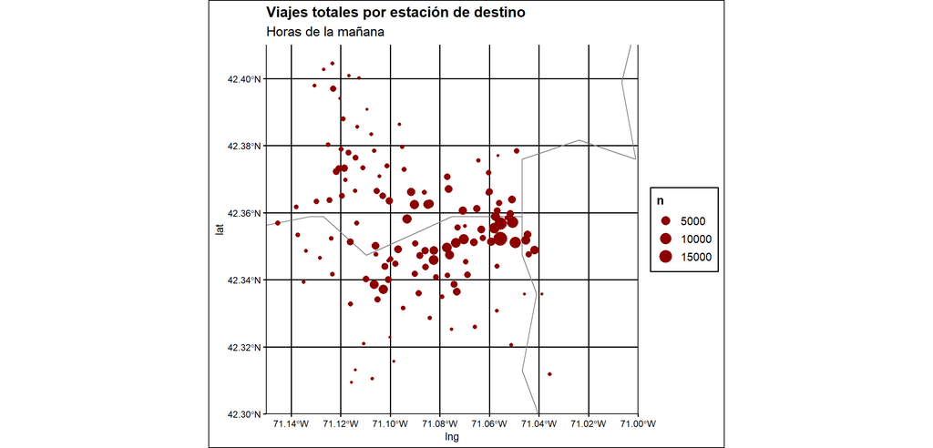

```r
ggplot(data = world) +
  geom_sf(data = counties, fill = NA, color = gray(.5)) +
  geom_point(
    data = estaciones_morn_destino, aes(x = lng, y = lat, size = n),
    color = "darkred"
  ) +
  coord_sf(xlim = c(-71.15, -71.0), ylim = c(42.3, 42.41), expand = FALSE) +
  labs(
    title = "Viajes totales por estación de destino",
    subtitle = "Horas de la mañana"
  ) +
  theme_clean()
```

*En la tarde:*

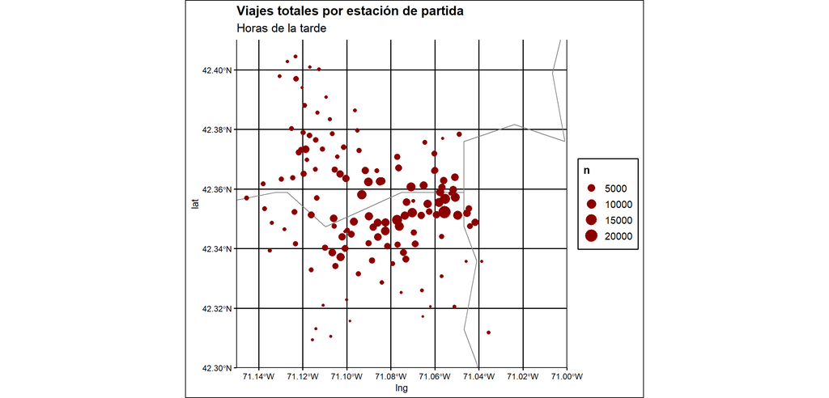

```r
ggplot(data = world) +
  geom_sf(data = counties, fill = NA, color = gray(.5)) +
  geom_point(
    data = estaciones_late, aes(x = lng, y = lat, size = n),
    color = "darkred"
  ) +
  coord_sf(xlim = c(-71.15, -71.0), ylim = c(42.3, 42.41), expand = FALSE) +
  labs(
    title = "Viajes totales por estación de partida",
    subtitle = "Horas de la tarde"
  ) +
  theme_clean()
```

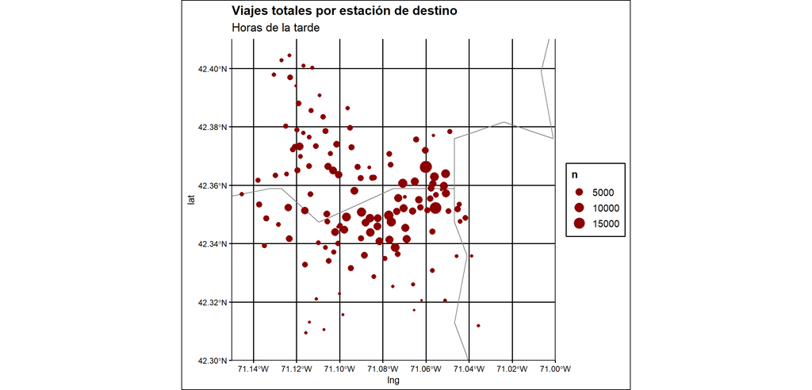

```r
ggplot(data = world) +
  geom_sf(data = counties, fill = NA, color = gray(.5)) +
  geom_point(
    data = estaciones_late_destino, aes(x = lng, y = lat, size = n),
    color = "darkred"
  ) +
  coord_sf(xlim = c(-71.15, -71.0), ylim = c(42.3, 42.41), expand = FALSE) +
  labs(
    title = "Viajes totales por estación de destino",
    subtitle = "Horas de la tarde"
  ) +
  theme_clean()
```

Estas conductas son normales en muchas ciudades con un centro geográfico laboral importante. Sin embargo, esto puede generar disparidades en la disponibilidad de bicicletas en las estaciones, lo cual es el motivo de este trabajo.

Analizando la distribución de las estaciones más concurridas se observa que tanto para estación de inicio como de Fin las estaciones mas concurridas son: *South Station - 700 Atlantic Ave.* Boston Public Library - 700 Boylston St. *Charles Circle - Charles St. at Cambridge St.

Todo el día: estaciones de fin

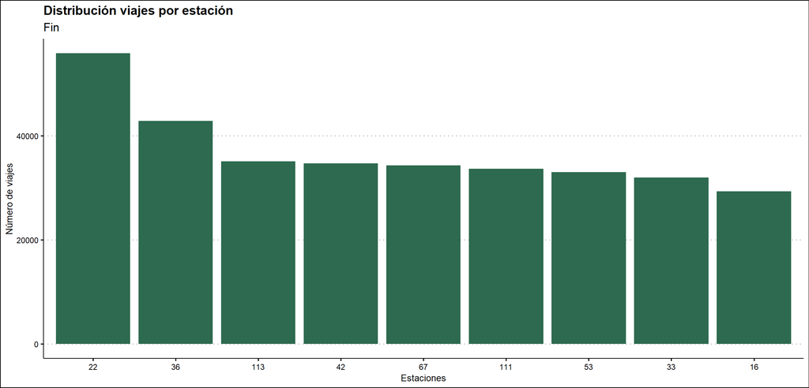

```r
ranking_end_t %>%
  filter(rank_e < 10) %>%
  ggplot(aes(x = reorder(end_statn, -N), y = N)) +
  geom_bar(stat = "identity", fill = "#2d6a4f") +
  labs(
    title = "Distribución viajes por estación",
    subtitle = "Fin",
    x = "Estaciones",
    y = "Número de viajes"
  ) +
  theme_clean()
```

*Análisis climatológico*

Otro factor a considerar es el de la lluvia. Es de esperarse que cuando llueve la gente use menos las bicicletas. Aunque son relativamente pocas las observaciones de viajes que hacen match con una hora donde hubo lluvia, se puede observar que en promedio esos viajes duraron menos. En promedio, los viajes sin lluvia duran alrededor de 3 minutos más en comparación.

Las siguientes gráficas muestran la duración promedio por hora en la que se inició para días entre semana y fin de semana. Se puede observar que los viajes con lluvia duran menos en promedio para prácticamente todas las horas.

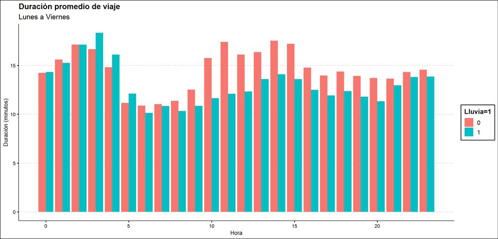

```r
#Entre semana
trips %>%
  group_by(hour, rain) %>%
  filter(day_w != 7 & day_w != 1) %>%
  summarise(duracion = mean(duration), sd = sd(duration), n = n()) %>%
  ggplot(aes(x = hour, y = duracion / 60, fill = as.factor(rain))) +
  geom_col(position = "dodge") +
  labs(
    title = "Duración promedio de viaje",
    subtitle = "Lunes a Viernes",
    x = "Hora",
    y = "Duración (minutos)",
    fill = "Lluvia=1"
  ) +
  theme_clean()
```

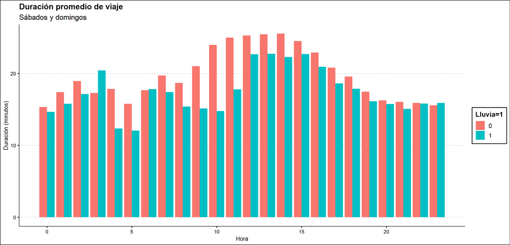

```r
#Fines de semana
trips %>%
  group_by(hour, rain) %>%
  filter(day_w == 7 | day_w == 1) %>%
  summarise(duracion = mean(duration), sd = sd(duration), n = n()) %>%
  ggplot(aes(x = hour, y = duracion / 60, fill = as.factor(rain))) +
  geom_col(position = "dodge") +
  labs(
    title = "Duración promedio de viaje",
    subtitle = "Sábados y domingos",
    x = "Hora",
    y = "Duración (minutos)",
    fill = "Lluvia=1"
  ) +
  theme_clean()
```

# 4. Análisis de predicción

## 4.1 Modelos para duración

A partir de las variables que se identifica que influyen en las distribuciones de duraciones y número de viajes, se exploraron algunos modelos de predicción de la duración y otros intentando predecir el **logaritmo** de la duración.

Esto último debido a la distribución de la duración tiene lo que se conoce como *colas pesadas*. Se tienen observaciones cuyo valor es varios órdenes de magnitud más grandes que los del promedio de la distribución.

Cuando la información de la duración es mapeada con un logaritmo, los valores son convertidos a una escala mucho más comparable, y la masa de la distribución de las observaciones se encuentra concentrada en una región mucho más acotada además de que visualmente se parece a una distribución familiar.

Esto lo podemos ver en la siguiente gráfica.

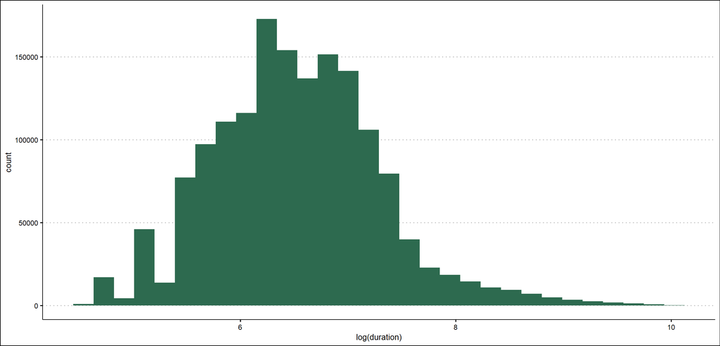

```r
trips %>%
  filter(90 < duration & duration < exp(10)) %>%
  ggplot(aes(x = log(duration))) +
  geom_histogram(fill = "#2d6a4f") +
  theme_clean()
```

La idea es la siguiente: dada la información con que se cuenta **al momento en el que la persona se acerca a la estación de bicicletas**, predecir la duración de su viaje. Aquí todavía no sabemos adónde va.

**FDR**

Se propone un modelo FDR sobre variables al momento de llegar a una estación.

Se utilizan las siguientes variables categóricas - Mes - Día de la semana - Hora - Estación de inicio. - Si es usuario registrado - Si es mujer - Si está al menos chispeando

Y la siguiente variable continua - Intensidad de la lluvia

A partir de estas variables predecimos la siguiente - Logaritmo de la duración

Este modelo nos indica que se tienen 147 variables significativas.

El código que genera las predicciones de este modelo se puede encontrar en el archivo “src/fdr.Rmd”.

Las predicciones, junto con las de todos los modelos, se encuentran guardadas en el archivo “data/interim/duracion.RData”.

**TREE**

Se estima un tree sencillo.

Se utilizan las siguientes variables categóricas - Estación de inicio - Mes - Día de la semana - **Hora** de inicio del viaje - Si es usuario registrado - Si es mujer - Si está al menos chispeando

Y la siguiente variable continua - Intensidad de la lluvia

A partir de estas variables predecimos la siguiente - Logaritmo de la duración

El código que genera las predicciones de este modelo se puede encontrar en el archivo “src/el_tri.Rmd”.

Las predicciones generadas se encuentran en el archivo “data/interim/duracion.RData”.

**TREE 2**

¿Y qué pasa si en vez de indicadora por hora le damos una variable continua que vaya del 0 al 24 y que indique el punto en el tiempo del día donde se tomó la bicicleta? Se estima un tree sencillo cambiando la indicadora de hora por una variable de tiempo.

Se utilizan las siguientes variables categóricas - Mes - Día de la semana - Estación de inicio - Si es usuario registrado - Si es mujer - Si está al menos chispeando

Y la siguiente variable continua - Intensidad de la lluvia - Tiempo (considerando el día medido como el intervalo *[0,24)*)

A partir de estas variables predecimos la siguiente - Logaritmo de la duración

El código que genera las predicciones de este modelo se puede encontrar en la segunda sección del archivo “src/el_tri.Rmd”.

Las predicciones generadas se encuentran en el archivo “data/interim/duracion.RData”.

**RANDOM FOREST**

También podemos intentar, en vez de intentar predecir el logaritmo de la duraciòn, predecir la duraciòn medida en segundos. Para esto usaremos un random forest.

Se utilizan las siguientes variables categóricas - Número de bicicleta - Mes - Día de la semana - Si es un usuario registrado - Si es mujer - Si está al menos chispeando - Hora

Y la siguientes variables numéricas - Año de nacimiento de la persona - Intensidad de la lluvia

A partir de estas variables predecimos la siguiente - Duración

El código que genera las predicciones de este modelo se puede encontrar en la segunda sección del archivo “src/Random_Forest.Rmd”.

Las predicciones generadas se encuentran en el archivo “data/interim/duracion.RData”.

**LASSO**

Se intentó un lasso sin embargo su status es no exitoso.

Se utilizan las siguientes variables categóricas - Mes - Día de la semana - **Hora** de inicio del viaje - Estación de inicio - Si es usuario registrado - Si es mujer - Si está al menos chispeando

Y la siguiente variable continua - Intensidad de la lluvia

A partir de estas variables predecimos la siguiente - Logaritmo de la duración

El código de este modelo se puede encontrar en el archivo “src/lassi.Rmd”.

Se obtiene el siguiente error.

`Error in h(simpleError(msg, call)) : error in evaluating the argument 'x' in selecting a method for function 't': 4 nodes produced errors; first error: lambda.min.ratio <= 1 is not TRUE`

## 4.2 Modelos para número de bicis por estación

En estos modelos se intenta predecir el número de bicicletas que llega a cada estación considerando la información que se tiene en cada estación en una ventana de tiempo dada (10 minutos).

Para esto se jugó con los datos originales para generar otra base con el conteo de bicicletas que llegaron por estación por cada intervalo de tiempo (10 minutos) del periodo de observación.

Se propone un modelo OLS con las siguientes consideraciones.

Se utilizan las siguientes variables categóricas - Estaciòn de llegada - Mes del año - Día de la semana - Intervalo de tiempo (se dividen las 24 horas del dìa en intervalos de 10 minutos). - Si está lloviendo

A partir de estas variables predecimos la siguiente - Número de bicis que llegan a la estación.

Adicional a esto, y como exploración, se estima un modelo exactamente igual pero considerando intervalos de media hora.

Se consideró un modelo tree, sin embargo al querer usar una categórica por estación de llegada no se acepta debido a que se tiene la restricción de poder usar categóricas con hasta 32 valores.

El modelo LASSO de igual manera no convirgió, por lo que se acudió a un OLS simple.

Los modelos y predicciones de este modelo se encuentran en el archivo “/src/llegadas.Rmd”.

## 4.3 Ideas para trabajo a futuro

Nos parece que, en caso de contemos con los recursos a futuro para continuar con nuestras investigaciones, uno de los predictores deseables serìa un predictor de **ruta**, donde ruta está entendida como una combinaciòn (i,j) de valores que representa ir de la estaciòn i a la estaciòn j. No es lo mismo (3,4) que (4,3), pues el orden importa.

Creemos que se tiene suficiente informaciòn como para poder predecir de manera razonable un random forest con las variables que se conocen al momento en que el usuario se acerca a la estaciòn.

# 5. Evaluación de modelos

```r
load('data/interim/duracion.RData')
```

## 5.1 Predicciones para duración de viaje

Veamos la distribución de los errores de predicción de los distintos modelos propuestos.

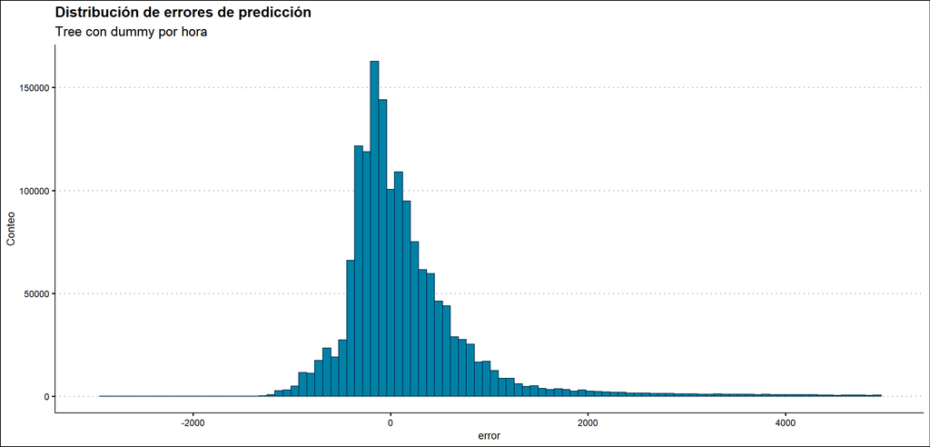

```r
duracion %>%
  ggplot(aes(x = duration - tri_1)) +
  # geom_histogram(bins = 100) +
  geom_histogram(bins = 100, color = "#003049", fill = "#0081a7") +
  ggthemes::theme_clean() +
  scale_x_continuous(limits = c(-6000, 6000)) +
  labs(
    x = "error",
    y = "Conteo",
    title = "Distribución de errores de predicción",
    subtitle = "Tree con dummy por hora"
  )+xlim(-3000,5000)
```

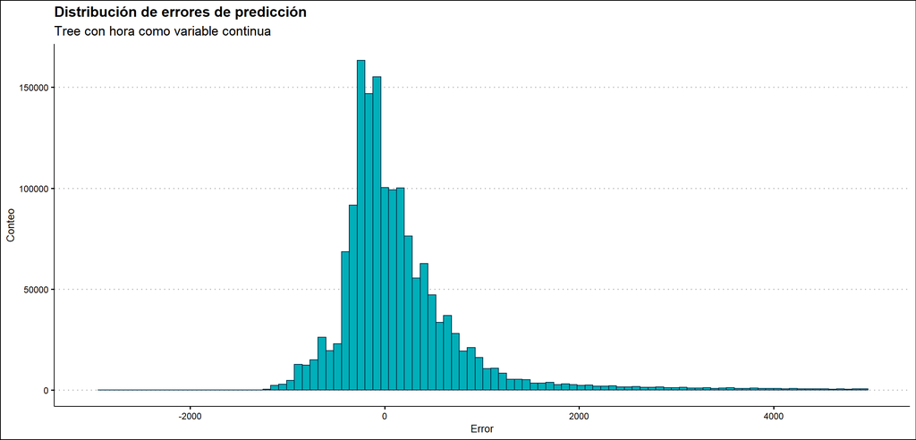

```r
duracion %>%
  ggplot(aes(x = duration - tri_2)) +
  geom_histogram(bins = 100, color = "#003049", fill = "#00afb9") +
  # geom_histogram(bins = 100) +
  ggthemes::theme_clean() +
  scale_x_continuous(limits = c(-6000, 6000)) +
  labs(
    x = "Error",
    y = "Conteo",
    title = "Distribución de errores de predicción",
    subtitle = "Tree con hora como variable continua"
  )+xlim(-3000,5000)
```

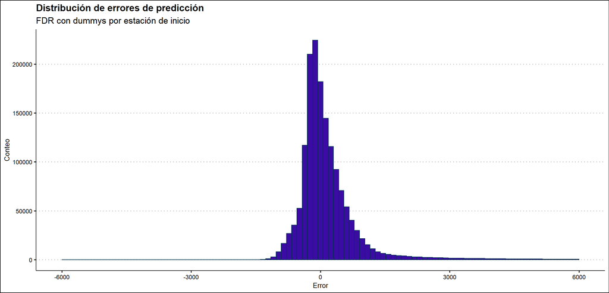

```r
duracion %>%
  ggplot(aes(x = duration - fdr1)) +
  geom_histogram(bins = 100, color = "#003049", fill = "#3a0ca3") +
  ggthemes::theme_clean() +
  scale_x_continuous(limits = c(-6000, 6000)) +
  labs(
    x = "Error",
    y = "Conteo",
    title = "Distribución de errores de predicción",
    subtitle = "FDR con dummys por estación de inicio"
  )
```

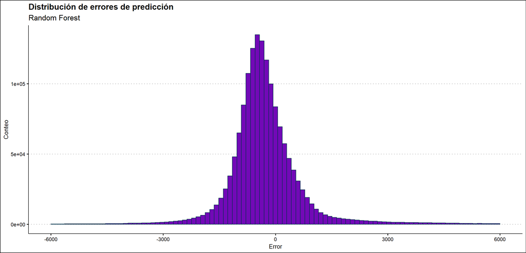

```r
duracion %>%
  ggplot(aes(x = duration - RF)) +
  geom_histogram(bins = 100, color = "#003049", fill = "#7209b7") +
  ggthemes::theme_clean() +
  scale_x_continuous(limits = c(-6000, 6000)) +
  labs(
    x = "Error",
    y = "Conteo",
    title = "Distribución de errores de predicción",
    subtitle = "Random Forest"
  )
```

Podemos observar que, si bien son cualitativamente similares, la distribuciòn del random forest se encuentra distribuída en un rango más amplio de valores que los otros modelos.

## 5.2 Estadísticos de la distribución de errores

Ahora fijémonos en estadísticos de la distribución de los errores de predicción.

**Error medio**

```r
duracion %>%
  mutate(
    e_tri_1 = abs(duration - tri_1),
    e_tri_2 = abs(duration - tri_2),
    e_fdr_1 = abs(duration - fdr1),
    e_rf = abs(duration - RF)
  ) %>%
  group_by(training_sample) %>%
  summarise(across(c("e_tri_1", "e_tri_2", "e_fdr_1", "e_rf"), ~ mean(.x, na.rm = TRUE))) %>%
  DT::datatable() %>%
  DT::formatRound(columns = c("e_tri_1","e_tri_2", "e_fdr_1", "e_rf"), digits = 1)
```

|  | training_sample | e_tri_1 | e_tri_2 | e_fdr_1 | e_rf |
| --- | --- | --- | --- | --- | --- |
| 1 | 0 | 508.63507486436 | 509.61764608828 | 502.091054654397 | 836.767816171203 |
| 2 | 1 | 509.61196657873 | 510.432988857953 | 502.903255712452 | 837.037141566917 |

**Medianas del error**

```r
duracion %>%
  mutate(
    e_tri_1 = abs(duration - tri_1),
    e_tri_2 = abs(duration - tri_2),
    e_fdr_1 = abs(duration - fdr1),
    e_rf = abs(duration - RF)
  ) %>%
  group_by(training_sample) %>%
  summarise(across(c("e_tri_1", "e_tri_2", "e_fdr_1", "e_rf"), ~ median(.x, na.rm = TRUE))) %>%
  DT::datatable() %>%
  DT::formatRound(columns = c("e_tri_1","e_tri_2", "e_fdr_1", "e_rf"), digits = 1)
```

|  | training_sample | e_tri_1 | e_tri_2 | e_fdr_1 | e_rf |
| --- | --- | --- | --- | --- | --- |
| 1 | 0 | 267.452665132673 | 277.592317469095 | 263.471816279477 | 547.97113079137 |
| 2 | 1 | 268.027239817181 | 278.642463472567 | 263.679912598722 | 547.550487320553 |

```r
# save(duracion, file = "data/interim/duracion.RData")
```

Podemos concluir que el modelo ganar es el **FDR**.

## 5.3 Predicciones de número de bicis por estación

```r
load('data/interim/llegada_10.RData')
```

**Error medio in sample y out of sample**

```r
llegada %>%
  mutate(e = abs(n - n_pred)) %>%
  group_by(training_sample) %>%
  summarise(across(c("e"), ~ mean(.x, na.rm = TRUE))) %>%
  DT::datatable() %>%
  DT::formatRound(columns = "e", digits = 3)
```

|  | training_sample | e |
| --- | --- | --- |
| 1 | 0 | 0.603051566892811 |
| 2 | 1 | 0.601318186512189 |

**Medianas del error in sample y out of sample**

```r
llegada %>%
  mutate(e = abs(n - n_pred)) %>%
  group_by(training_sample) %>%
  summarise(across(c("e"), ~ median(.x, na.rm = TRUE))) %>%
  DT::datatable() %>%
  DT::formatRound(columns = "e", digits = 3)
```

|  | training_sample | e |
| --- | --- | --- |
| 1 | 0 | 0.459174112107497 |
| 2 | 1 | 0.459614960698019 |

¡Pareciera ser un modelo muy bueno! Sin embargo esa creencia se disipa cuando calculamos el promedio de bicicletas que llegaron por estación por intervalo de tiempo.

```r
mean(llegada$n)
```

```
## [1] 1.472634
```

Esto nos hace sospechar que para estaciones concurridas el modelo no lo hace tan bien. En la siguiente tabla la variable n es el número de bicis que llegaron en el intervalo más saturado y la predicción del modelo.

```r
llegada %>%
  arrange(desc(n)) %>%
  select(-anho_fin, -dia_fin, -rain, -training_sample) %>%
  head() %>%
  DT::datatable() %>%
  DT::formatRound(columns = "n_pred", digits = 1)
```

|  | end_statn | mes_fin | dsem_fin | intervalo | n | n_pred |
| --- | --- | --- | --- | --- | --- | --- |
| 1 | 67 | 10 | 7 | 16.1 | 20 | 2.03246629464724 |
| 2 | 114 | 9 | 5 | 17.2 | 20 | 2.82225673425071 |
| 3 | 111 | 9 | 2 | 17.1 | 19 | 2.42161293201478 |
| 4 | 114 | 10 | 4 | 17 | 19 | 2.70687512731247 |
| 5 | 111 | 6 | 2 | 17.1 | 18 | 2.41209112798018 |
| 6 | 111 | 8 | 3 | 17.1 | 18 | 2.4491709300462 |

Si vemos el histograma con el conteo de bicis que llegan por estación se observa que casi todas las observaciones tienen un uno o un dos. Es por esto que para nuestro modelo predecir un 2 es la respuesta más sensata.

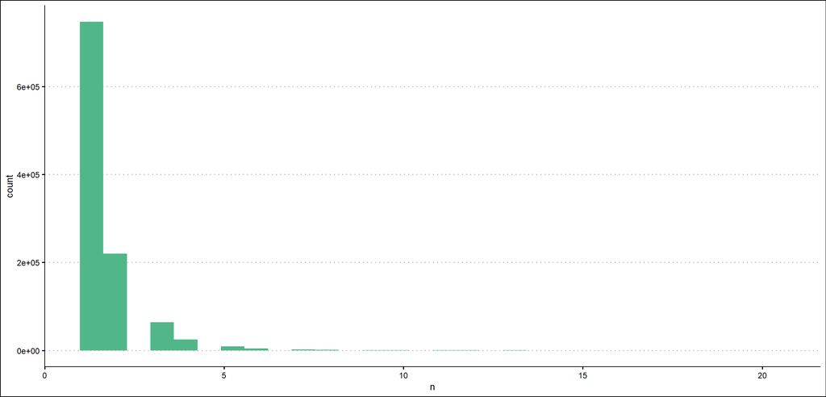

```r
llegada %>%
  ggplot(aes(x = n)) +
  geom_histogram(fill = "#52b788") +
  theme_clean()
```

Podríamos decir que el modelo es exitoso, sin embargo no es muy útil.

Si repetimos este modelo pero usando una ventana de media hora, tenemos lo siguiente.

```r
load('data/interim/llegada_30.RData')
```

Las medias y medianas de errores es menos buena.

**Error medio in sample y out of sample**

```r
llegada %>%
  mutate(e = abs(n - n_pred_30)) %>%
  group_by(training_sample) %>%
  summarise(across(c("e"), ~ mean(.x, na.rm = TRUE))) %>%
  DT::datatable() %>%
  DT::formatRound(columns = "e", digits = 2)
```

|  | training_sample | e |
| --- | --- | --- |
| 1 | 0 | 1.01084112149533 |
| 2 | 1 | 1.0055349961324 |

**Medianas del error in sample y out of sample**

```r
llegada %>%
  mutate(e = abs(n - n_pred_30)) %>%
  group_by(training_sample) %>%
  summarise(across(c("e"), ~ median(.x, na.rm = TRUE))) %>%
  DT::datatable() %>%
  DT::formatRound(columns = "e", digits = 2)
```

|  | training_sample | e |
| --- | --- | --- |
| 1 | 0 | 1 |
| 2 | 1 | 1 |

Pero es menos mala prediciendo intervalos populares.

```r
llegada %>%
  arrange(desc(n)) %>%
  select(-anho_fin, -dia_fin, -rain, -training_sample) %>%
  head() %>%
  DT::datatable()
```

|  | end_statn | mes_fin | dsem_fin | intervalo | n | n_pred_30 |
| --- | --- | --- | --- | --- | --- | --- |
| 1 | 114 | 10 | 2 | 17 | 44 | 5 |
| 2 | 114 | 10 | 4 | 17 | 44 | 5 |
| 3 | 114 | 9 | 4 | 17 | 43 | 5 |
| 4 | 111 | 6 | 2 | 17 | 40 | 4 |
| 5 | 114 | 5 | 3 | 17 | 39 | 5 |
| 6 | 114 | 10 | 5 | 17 | 39 | 5 |

Gracias.